# projet-Exam-Data-Anna-Lise

2023-04-05

```r
library(tidyverse)
```

```r
library(gapminder)
library(dplyr)
library(ggplot2)
library(questionr)
library(readxl)
```

Intro Problématique : Comment l’IPS qui représente les inégalités au sein des lycées en fonction des CSP des parents est traduit ou non par un écart de revenu sur le territoire en Creuse ?

# Titre partie 1

On commence par s’intéresser au nombre de lycées en Creuse et on le compare au niveau national.

```r
lycees_ips <-  read.csv("fr-en-ips_lycees.csv", sep=";")
lycees_ips_19_20 <-lycees_ips %>% filter(rentree_scolaire == "2019-2020")
num_lycee <- length(unique(lycees_ips_19_20$uai))
num_lycee
```

```
## [1] 3621
```

On a 3621 lycées en France.

```r
lycees_ips_creuse <-lycees_ips_19_20 %>% filter(departement == "CREUSE")
num_lycee_creuse <- length(unique(lycees_ips_creuse$uai))
num_lycee_creuse
```

```
## [1] 8
```

On a 8 lycee en creuse. Regardons combien un departement a de lycee.

```r
freq_lycees_dep <- lycees_ips_19_20
freq_lycees_dep #lui je l'afficherai pas
```

[output not shown]

[output cut: 21717 more lines]

```r
num_lycee_par_dep <- lycees_ips_19_20 %>% group_by(code_du_departement) %>% summarize(num_lycee= n_distinct(uai),)
num_lycee_par_dep[order(num_lycee_par_dep$num_lycee),]
```

```
## # A tibble: 101 × 2
##    code_du_departement num_lycee
##    <chr>                   <int>
##  1 02A                         7
##  2 02B                         8
##  3 23                          8
##  4 48                          8
##  5 15                          9
##  6 90                          9
##  7 4                          10
##  8 5                          10
##  9 11                         11
## 10 36                         11
## # ℹ 91 more rows
```

Avec les deux departements de Corse et le 48, la Creuse est le departement avec le moins de lycée en France.

# Comparaison part des terminales générales vs pro

Maintenant on veut voir s’il y a une différence de représentation entre les lycées en général et professionnel. On va comparer la proportion d’élèves en terminale pro vs générale.

```r
effectifs_lycees <-read_delim("fr-en-lycee_gt-effectifs-niveau-sexe-lv.csv", delim = ";", col_names = T, show_col_types = FALSE)

#On sélectionne seulement les colonnes qui nous intéresse et l'année 2019.
effectifs_lycees_2019 <- effectifs_lycees %>% filter(rentree_scolaire == "2019")

term_2019 <- effectifs_lycees_2019 %>% select(departement,terminales_g, terminales_sti2d,terminales_stl,terminales_stmg,terminales_st2s,terminales_std2a,terminales_sthr,terminales_tmd,terminales_bt)

tot_term_fr <- colSums(term_2019[, c("terminales_g", "terminales_sti2d",
"terminales_stl","terminales_stmg","terminales_st2s","terminales_std2a",
"terminales_sthr","terminales_tmd","terminales_bt")])
tot_term_fr
```

```
##     terminales_g terminales_sti2d   terminales_stl  terminales_stmg
##           386975            34862             9060            78165
##  terminales_st2s terminales_std2a  terminales_sthr   terminales_tmd
##            23738             3540             2373              321
##    terminales_bt
##              224
```

```r
term_creuse_2019 <- term_2019 %>% filter(departement == "CREUSE")
nrow(term_creuse_2019)
```

```
## [1] 4
```

On remarque qu’il y a seulement les données de 4 lycées en Creuse pour l’année 2019. Il faut en tenir compte lors des analyses car peu représentatif.

```r
tot_term_creuse <- colSums(term_creuse_2019[, c("terminales_g", "terminales_sti2d","terminales_stl","terminales_stmg","terminales_st2s","terminales_std2a","terminales_sthr","terminales_tmd","terminales_bt")])
tot_term_creuse
```

```
##     terminales_g terminales_sti2d   terminales_stl  terminales_stmg
##              402               33               34               60
##  terminales_st2s terminales_std2a  terminales_sthr   terminales_tmd
##               49               34                0                0
##    terminales_bt
##                0
```

```r
#On regroupe les infos dans des tableaux
type_term <- c("terminales_g", "terminales_sti2d",
               "terminales_stl","terminales_stmg",
               "terminales_st2s","teminales_std2a",
               "terminales_sthr","terminales_tmd",
               "terminales_bt")
tab_term_fr <- data_frame(type_term, tot_term_fr)
prop_term_fr <- transform(tab_term_fr, proportion = tot_term_fr / sum(tot_term_fr))
prop_term_fr #ça répète celui de fin
```

```
##                         type_term tot_term_fr   proportion
## terminales_g         terminales_g      386975 0.7176064147
## terminales_sti2d terminales_sti2d       34862 0.0646480905
## terminales_stl     terminales_stl        9060 0.0168008634
## terminales_stmg   terminales_stmg       78165 0.1449491709
## terminales_st2s   terminales_st2s       23738 0.0440197457
## terminales_std2a  teminales_std2a        3540 0.0065645758
## terminales_sthr   terminales_sthr        2373 0.0044004910
## terminales_tmd     terminales_tmd         321 0.0005952624
## terminales_bt       terminales_bt         224 0.0004153856
```

```r
tab_term_creuse <- data_frame(type_term, tot_term_creuse)
prop_term_creuse <- transform(tab_term_creuse, proportion = tot_term_creuse / sum(tot_term_creuse))
prop_term_creuse #pareil ça répète celui d'après
```

```
##                         type_term tot_term_creuse proportion
## terminales_g         terminales_g             402 0.65686275
## terminales_sti2d terminales_sti2d              33 0.05392157
## terminales_stl     terminales_stl              34 0.05555556
## terminales_stmg   terminales_stmg              60 0.09803922
## terminales_st2s   terminales_st2s              49 0.08006536
## terminales_std2a  teminales_std2a              34 0.05555556
## terminales_sthr   terminales_sthr               0 0.00000000
## terminales_tmd     terminales_tmd               0 0.00000000
## terminales_bt       terminales_bt               0 0.00000000
```

```r
tab_prop_term <- left_join(prop_term_fr, prop_term_creuse, by="type_term")
tab_prop_term
```

```
##          type_term tot_term_fr proportion.x tot_term_creuse proportion.y
## 1     terminales_g      386975 0.7176064147             402   0.65686275
## 2 terminales_sti2d       34862 0.0646480905              33   0.05392157
## 3   terminales_stl        9060 0.0168008634              34   0.05555556
## 4  terminales_stmg       78165 0.1449491709              60   0.09803922
## 5  terminales_st2s       23738 0.0440197457              49   0.08006536
## 6  teminales_std2a        3540 0.0065645758              34   0.05555556
## 7  terminales_sthr        2373 0.0044004910               0   0.00000000
## 8   terminales_tmd         321 0.0005952624               0   0.00000000
## 9    terminales_bt         224 0.0004153856               0   0.00000000
```

Ce tableau permet de voir la répartition des élèves entre les différentes terminales. Il est difficile d’en tirer des observations donc on va réaliser un graphique pour que ce soit plus visuel.

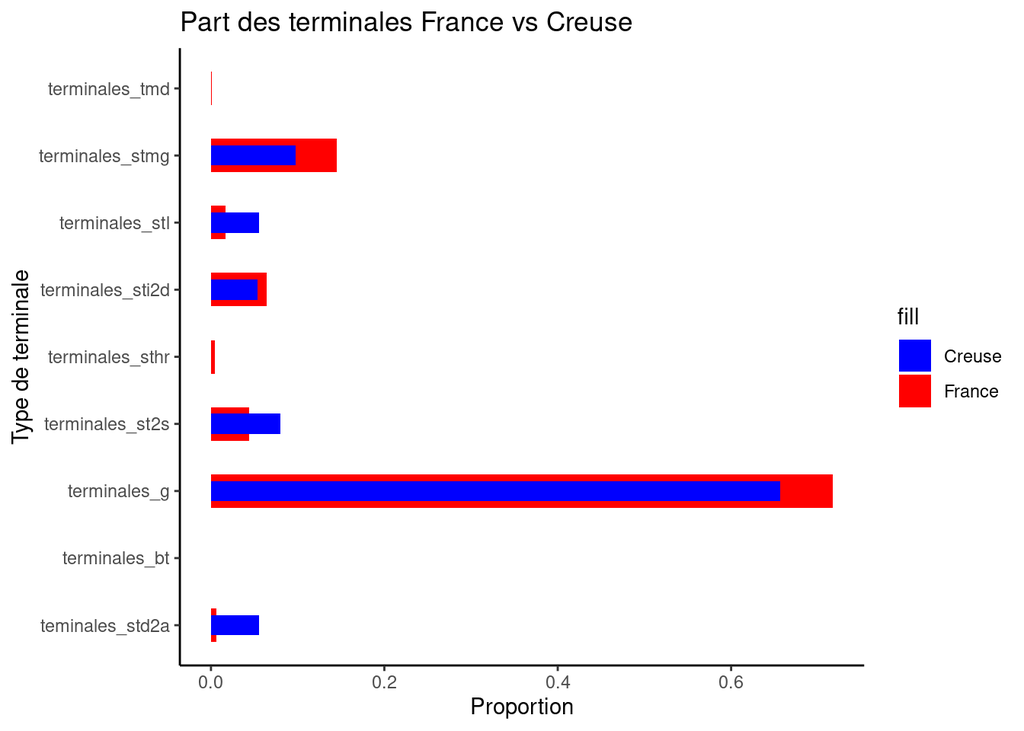

```r
ggplot(tab_prop_term, aes(y = type_term)) +
  geom_bar(aes(x = proportion.x, fill = "France"), stat = "identity", position = "dodge", width = 0.5) +
  geom_bar(aes(x = proportion.y, fill = "Creuse"), stat = "identity", position = "dodge", width = 0.3) +
  scale_fill_manual(values = c("France" = "red", "Creuse" = "blue")) +
  labs(x = "Proportion", y = "Type de terminale", title = "Part des terminales France vs Creuse") +
  theme_classic()
```

Conclu de la partie : Rappel que peu représentatif car données sur seulemnt 4 lycées en Creuse. On remarque que certaines terminales ne sont pas du tout représenté en Creuse. > moins de diversité et d’opportunité Une proportion supérieur de lycéens en voie professionnelle en Creuse comparé à la France. Donc logiquement et proportionnellement, moins de lycéens suivent une terminale en général en Creuse.

L’indice de position sociale (IPS) des élèves est un outil de mesure quantitatif de la situation sociale des élèves face aux apprentissages dans les établissements scolaires français. Plus l’indice est élevé, plus l’élève évolue dans un contexte familial favorable aux apprentissages. On a choisi de comparer l’IPS de la Creuse à celui de la France pour comparer la position du département.

```r
mean(lycees_ips_creuse$ips_ensemble_gt_pro)
```

```
## [1] 98.275
```

```r
mean(lycees_ips_19_20$ips_ensemble_gt_pro)
```

```
## [1] 103.2637
```

On remarque déjà une différence d’IPS entre l’IPS nationale et en Creuse. Regardons de plus près si cela se différencie entre les voies professionnelles et générales.

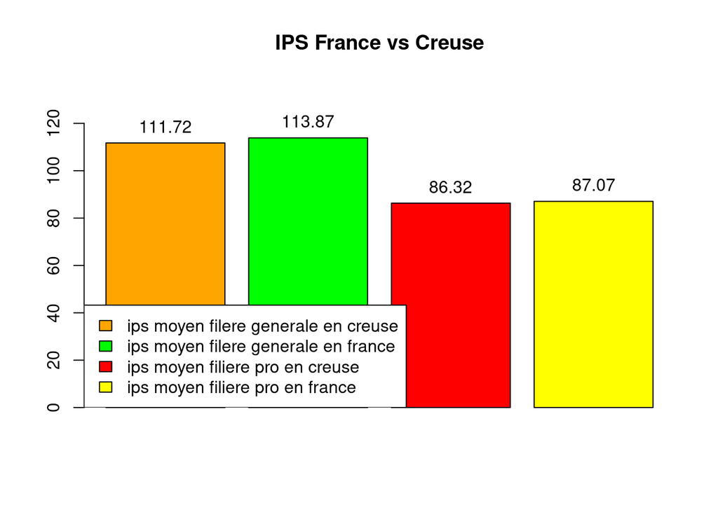

```r
mean_gt <- mean(lycees_ips_creuse$ips_voie_gt,na.rm = TRUE)
mean_pro <- mean(lycees_ips_creuse$ips_voie_pro,na.rm = TRUE)
mean_nat_gt <- mean(lycees_ips_19_20$ips_voie_gt,na.rm = TRUE)
mean_nat_pro <- mean(lycees_ips_19_20$ips_voie_pro,na.rm = TRUE)

values = c(mean_gt,mean_nat_gt,mean_pro,mean_nat_pro)
barplot(values,col = c("orange","green","red","yellow"),ylim = c(0,max(values)*1.2), main = "IPS France vs Creuse")
legend("bottomleft",
       legend = c("ips moyen filere generale en creuse","ips moyen filere generale en france", "ips moyen filiere pro en creuse", "ips moyen filiere pro en france"),
       fill = c("orange","green","red","yellow"))
text(x = c(0.7,1.9, 3.1,4.3), y = values, labels = round(values, 2), pos = 3)
```

# Répartition des professions France vs Creuse

Après avoir remarqué que la Creuse possède peu de lycée et un IPS en dessous de la moyenne nationale nous allons regarder ce qu’il passe au niveau des catégories professionnelles et voir si on peut en tirer des conclusions.

```r
cat_socio_pro <- read_delim("base-ic-activite-residents-2019.CSV",
                         delim = ";", col_names = T,
                         show_col_types = FALSE)

#On garde seulement les colonnes pertinentes pour l'analyse.
cat_socio_pro_bis <- cat_socio_pro %>% select(COM, P19_POP1564,C19_ACT1564_CS1, C19_ACT1564_CS3, C19_ACT1564_CS4, C19_ACT1564_CS6, P19_CHOM1564, P19_INACT1564)

#On renomme les colonnes pour faciliter la lecture
colnames(cat_socio_pro_bis)[2] ="Population"
colnames(cat_socio_pro_bis)[3] ="Agriculteur"
colnames(cat_socio_pro_bis)[4] ="Cadres_sup"
colnames(cat_socio_pro_bis)[5] ="Inter"
colnames(cat_socio_pro_bis)[6] ="Ouvriers"
colnames(cat_socio_pro_bis)[7] ="Chomeur"
colnames(cat_socio_pro_bis)[8] ="Inactif"

cat_socio_pro_bis <- cat_socio_pro_bis[complete.cases(cat_socio_pro_bis), ] #remove nan

#On fait un tableau seulement avec les données de la Creuse.
cat_socio_pro_creuse <- cat_socio_pro_bis %>% filter(stringr::str_starts(COM, '23'))
cat_socio_pro_creuse #trop long aussi comme tableau et pas intéressant je garderai seulement la somme
```

```
## # A tibble: 359 × 8
##    COM   Population Agriculteur Cadres_sup Inter Ouvriers Chomeur Inactif
##    <chr>      <dbl>       <dbl>      <dbl> <dbl>    <dbl>   <dbl>   <dbl>
##  1 2302        220.        0         24.9   64.9     30.1   13.0     46.7
##  2 2303        399.        0         66.9  146.      10.4   18.5    104.
##  3 2304       1733         0         41    195      406    358      558
##  4 2305       1731.        5.04      60.5  211.     538.   314.     482.
##  5 2306        324        10         10     55       95     36      103
##  6 2307       1267.        0         88.7  189.     342.   146.     309.
##  7 2308        305.       10.4        9.44  20.2     96.2   36.0     74.7
##  8 2309        440.       10.8       25.4   89.6     90.2   57.6     97.6
##  9 2310        165.        5.20       4.69  13.2     36.7   17.3     47.2
## 10 2311         80         0          0     14.0     27.9    3.72    13.0
## # ℹ 349 more rows
```

```r
#On fait la somme de chacune des catégories en France.
sum_cat <- colSums(cat_socio_pro_bis[, c("Population", "Agriculteur", "Cadres_sup", "Inter", "Ouvriers", "Chomeur", "Inactif"
)])
sum_cat
```

```
##  Population Agriculteur  Cadres_sup       Inter    Ouvriers     Chomeur
##  41684391.0    401421.5   5128401.9   7703030.2   6557260.4   4147039.5
##     Inactif
##  10775571.9
```

```r
# Même chose pour la Creuse
sum_cat_creuse <- colSums(cat_socio_pro_creuse[, c("Population", "Agriculteur", "Cadres_sup", "Inter", "Ouvriers", "Chomeur", "Inactif"
)])
sum_cat_creuse
```

```
##  Population Agriculteur  Cadres_sup       Inter    Ouvriers     Chomeur
##  107320.515    4431.952    6026.897   16409.891   20396.838   11195.673
##     Inactif
##   29171.779
```

```r
#On fait des tableaux pour regouper ces informations.
catégorie <- c("Population", "Agriculteur", "Cadres_sup", "Inter", "Ouvriers", "Chomeur", "Inactif"
)
#En France
tableau_sum_cat <- data_frame(catégorie, sum_cat)
tableau_sum_cat#répète celui de la fin
```

```
## # A tibble: 7 × 2
##   catégorie     sum_cat
##   <chr>           <dbl>
## 1 Population  41684391.
## 2 Agriculteur   401421.
## 3 Cadres_sup   5128402.
## 4 Inter        7703030.
## 5 Ouvriers     6557260.
## 6 Chomeur      4147039.
## 7 Inactif     10775572.
```

```r
#En Creuse
tableau_sum_cat_creuse <- data_frame(catégorie, sum_cat_creuse)
tableau_sum_cat_creuse #répète celui d'après
```

```
## # A tibble: 7 × 2
##   catégorie   sum_cat_creuse
##   <chr>                <dbl>
## 1 Population         107321.
## 2 Agriculteur          4432.
## 3 Cadres_sup           6027.
## 4 Inter               16410.
## 5 Ouvriers            20397.
## 6 Chomeur             11196.
## 7 Inactif             29172.
```

```r
tab_recap <- left_join(tableau_sum_cat, tableau_sum_cat_creuse, by="catégorie")
tab_recap #quasi pareil que celui d'après
```

```
## # A tibble: 7 × 3
##   catégorie     sum_cat sum_cat_creuse
##   <chr>           <dbl>          <dbl>
## 1 Population  41684391.        107321.
## 2 Agriculteur   401421.          4432.
## 3 Cadres_sup   5128402.          6027.
## 4 Inter        7703030.         16410.
## 5 Ouvriers     6557260.         20397.
## 6 Chomeur      4147039.         11196.
## 7 Inactif     10775572.         29172.
```

```r
#On veut les proportions de chaque catégories par rapport à la population totale.
tab_recap <-tab_recap %>% mutate(cat_proportion_fr = (sum_cat / first(sum_cat)) * 100, cat_proportion_creuse = (sum_cat_creuse / first(sum_cat_creuse)) * 100)
tab_recap
```

```
## # A tibble: 7 × 5
##   catégorie     sum_cat sum_cat_creuse cat_proportion_fr cat_proportion_creuse
##   <chr>           <dbl>          <dbl>             <dbl>                 <dbl>
## 1 Population  41684391.        107321.           100                    100
## 2 Agriculteur   401421.          4432.             0.963                  4.13
## 3 Cadres_sup   5128402.          6027.            12.3                    5.62
## 4 Inter        7703030.         16410.            18.5                   15.3
## 5 Ouvriers     6557260.         20397.            15.7                   19.0
## 6 Chomeur      4147039.         11196.             9.95                  10.4
## 7 Inactif     10775572.         29172.            25.9                   27.2
```